# Mendota_EpiVolume

Lauren A. Knose, ORISE-EPA

2023-08-25

The purpose of this program is to identify the thermocline depth from temperature profiles and calculate the volume change of the epilimnion for mass balance.

# Step 1. Load dependent packages and data:

1. loading dependent packages…

```r
library(ggplot2) #needed for plots
library(dplyr) #needed for reformatting data
library(rLakeAnalyzer) #needed to find thermocline depth from temperature profile
library(reshape2) #needed to reshape data frame from wide to long or long to wide
library(zoo) #needed to linearly interpolate missing values
```

Packages loaded.

2. loading dependent data…

```r
watertemp<-read.csv(file="Original_data/ntl29_v12_temp.csv") #data from temp string
```

Data loaded.

# Step 2. Define and filter the data:

defining and filtering data…

```r
watertemp2<- watertemp %>% #make new data frame
  mutate(sampledate=as.Date(sampledate, format="%m/%d/%Y",#specify format of date
                            origin="1899-12-30"), #tells R the origin for dates
         Depth_m=depth, depth=NULL, #rename column with units and remove duplicate
         watertemp_C=wtemp, wtemp=NULL,#rename column with units and remove duplicate
         daynum=as.integer(format(sampledate, format="%j")), #add in day number
         Yr=as.integer(format(sampledate, "%Y"))) %>% #add in year
  filter(lakeid=="ME") %>% #filter for Lake Mendota data only
  filter(rep==1) %>% #filter for rep 1 (no analytical reps)
  filter(!is.na(watertemp_C)) %>% #remove NAs
  filter(Yr>=2012 & Yr <=2018) %>% #filter for the study years
  filter(daynum>= 189 & daynum <=261) %>% #filter for CyanoHAB season +- 6 days
  select(sampledate, Depth_m, watertemp_C, daynum, Yr) #select vars needed
```

Water temperature data defined and filtered.

# Step 3. View the data available:

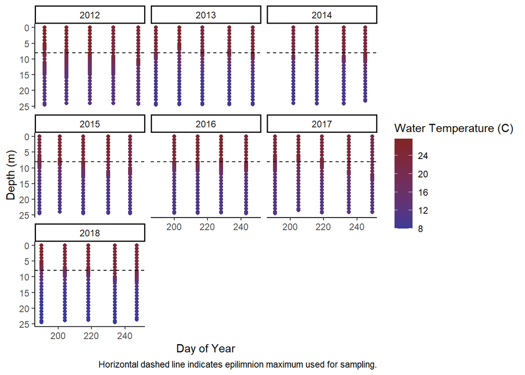

```r
epi_depth_m <- 8 #specify the bottom of the epilimnion depth sampled
ggplot(data=watertemp2, #create limno plot with depth inverse on y-axis
       aes(x=daynum, #sampled date as x-axis
           y=Depth_m,
           color=watertemp_C)) + #and data points colored by temperature
  geom_point() + #plot points
  facet_wrap(~Yr) + #make separate plot for each year
  scale_y_reverse() + #inverses the y-axis from zero to max(depth) for limno plot
  scale_color_gradient(high=scales::muted("red"), #red = hot temp
                        low=scales::muted("blue"), #blue = cold temp
                        name="Water Temperature (C)") + #name of legend
  geom_hline(yintercept=epi_depth_m, lty="dashed") + #add line for bottom of epi
  theme_classic() +
  labs(x="Day of Year", y="Depth (m)",
  caption="Horizontal dashed line indicates epilimnion maximum used for sampling.")
```

# Step 4. Calculate the thermocline depth for each observation:

Note, rLakeAnalyzer package is required here. Data frame needs to be in wide format with each depth a separate column (add prefix= “wtr_”) to match package function dependencies.

1. reshaping the data frame for package…

```r
wtr<- watertemp2 %>%
  select(sampledate, Depth_m, watertemp_C) #only include needed columns
wtr<- dcast(wtr, sampledate ~ Depth_m) # reshape data frame from long to wide
colnames(wtr)<- paste("wtr", colnames(wtr), sep="_") #add wtr_ before depth to
# fit package format dependencies
wtr<- wtr %>%
  mutate(datetime=wtr_sampledate, wtr_sampledate=NULL) #rename column to fit
# package format dependencies
```

Data frame reshaped and ready for input into the package.

2. using ts.thermo.depth function to calculate thermocline depth…

```r
t.d<- ts.thermo.depth(wtr, na.rm=TRUE) #calculates thermocline depth as time series
```

Thermocline depth calculated.

3. plotting the thermocline depth by day during CyanoHAB season…

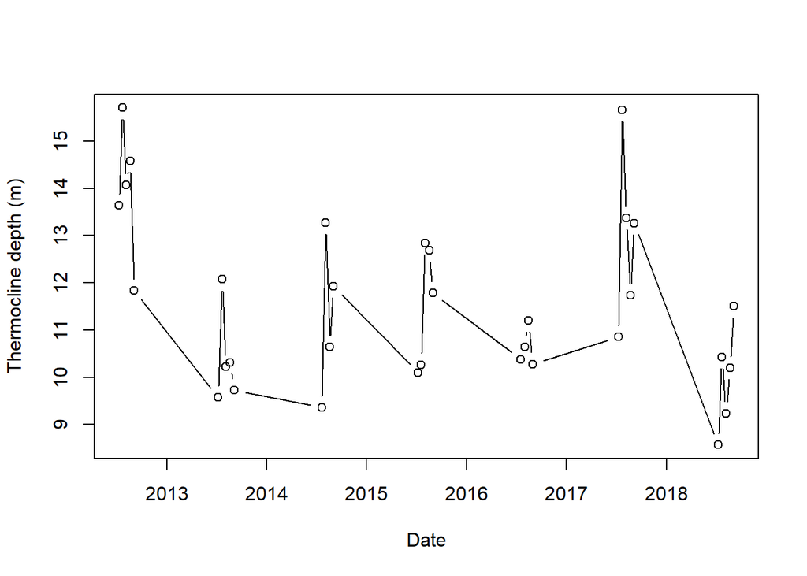

```r
plot(x=t.d$datetime, y=t.d$thermo.depth, type="b",
     xlab="Date",
     ylab="Thermocline depth (m)")
```

Thermocline depth calculated and plotted for each date.

# Step 5. Calculate the change in volume of epilimnion from change in thermocline

depth:

1. separating data by year, then assigning thermocline depth at t and t-1…

```r
t.d2<- t.d %>% #make new table
  mutate(Yr=as.numeric(format(datetime, "%Y"))) %>% #add in year
  group_by(Yr) %>% #for each year of day
  mutate(Thermo_depth_m=thermo.depth, thermo.depth=NULL, #add units and remove duplicate column
         Thermo_depth_m_k1=lag(Thermo_depth_m, n=1)) #thermocline depth at t-1
```

2. reassigning first thermocline depth at t-1 each year (NAs) as thermocline depth at t…

```r
t.d2$Thermo_depth_m_k1[is.na(t.d2$Thermo_depth_m_k1)] <- t.d2$Thermo_depth_m[is.na(t.d2$Thermo_depth_m_k1)]#replace NAs in t-1 with the t value
```

3. calculating change in thermocline depth between t and t-1 and change in epilimnion volume…

```r
A_strat= 25850000 # basin surface area of stratified region in m^2
Vol_epi<- t.d2 %>%
  mutate(Chg_Thermodepth_m = (Thermo_depth_m - Thermo_depth_m_k1),#calculate daily change in depth
         Vol_epi_m3 = Chg_Thermodepth_m*A_strat,#calculate daily change in volume
         sampledate=datetime, datetime=NULL, #rename column, remove duplicate
         daynum=as.numeric(format(sampledate, "%j")) #add in daynum
         )  %>%
  select(sampledate, Yr, daynum, Vol_epi_m3, Thermo_depth_m)
```

Change in epilimnion volume calculated between observations.

# Step 6. Bin observations into same day number each year:

1. defining expected observation frequencies based on sampling regime…

```r
Yr<- seq(from=2012, #define year start of study period
             to=2018, #define year end of study period
             by=1) #creates a sequence every 1 year
Yr #prints the expected years of data
```

```
## [1] 2012 2013 2014 2015 2016 2017 2018
```

```r
daynum_bins<- seq(from=196, #define date start of CyanoHAB season
                  to=255, #define date end of CyanoHAB season
                  by=14) #creates a sequence every 14 days
daynum_bins #prints the expected observation dates of data
```

```
## [1] 196 210 224 238 252
```

Defined expected observation frequency.

2. binning observed dates into expected dates…

```r
Vol_epi2<- Vol_epi %>%
mutate(daynum_bin=ifelse(daynum<(daynum_bins[2]-7), #if observation is <= bin 2 min
       daynum_bins[1], #yes returns bin 1
       ifelse(daynum>=(daynum_bins[2]-7)&daynum<(daynum_bins[3]-7),
              #if observation is > bin 2 min and <= bin 3 min
              daynum_bins[2], #yes returns bin 2
              ifelse(daynum>=(daynum_bins[3]-7)&daynum<(daynum_bins[4]-7),
                     #if observation is > bin 3 min and <= bin 4 min
                     daynum_bins[3], #yes returns bin 3
                     ifelse(daynum>=(daynum_bins[4]-7)&daynum<(daynum_bins[5]-7),
                            #if observation is > bin 4 min and <= bin 5 min
                            daynum_bins[4], #yes returns bin 4
                            daynum_bins[5])#no returns bin 5
                     )
              )
       )
)
Vol_epi2<- Vol_epi2 %>%
  filter(!duplicated(cbind(Yr, daynum_bin), fromLast = TRUE)) #remove duplicate
```

Observed dates assigned into closest expected dates.

# Step 7. Interpolate missing observations:

1. creating new data frame with expected values…

```r
Vol_epi3<- data.frame(# makes new data frame
                      daynum_bin=rep(daynum_bins, times=7), #creates field with
                      #expected observations (5/yr for 7 years)
                      Yr=rep(Yr, each= 5)) #creates field with expected yr
```

Table created with expected observation frequency.

2. merging the two data frames…

```r
Vol_epi3<- merge(Vol_epi3, Vol_epi2, #two data frames to join
                 by=c("Yr", "daynum_bin"), #join by year and day number
                 all.x=TRUE) #keep the predicted observation days
```

Data frames merged.

3. interpolating sample date from day and year…

```r
Vol_epi_int<- Vol_epi3 %>%
  group_by(Yr) %>% #within each year
  mutate(YrDay=paste(Yr, daynum_bin, sep="/"), #combined day of year and year
         date=as.Date(YrDay, format="%Y/%j", #convert  year, day to date
                      oorigin="1899-12-30")) %>%
  ungroup()
```

Missing sample dates interpolated.

4. interpolating change in epi volume between observations…

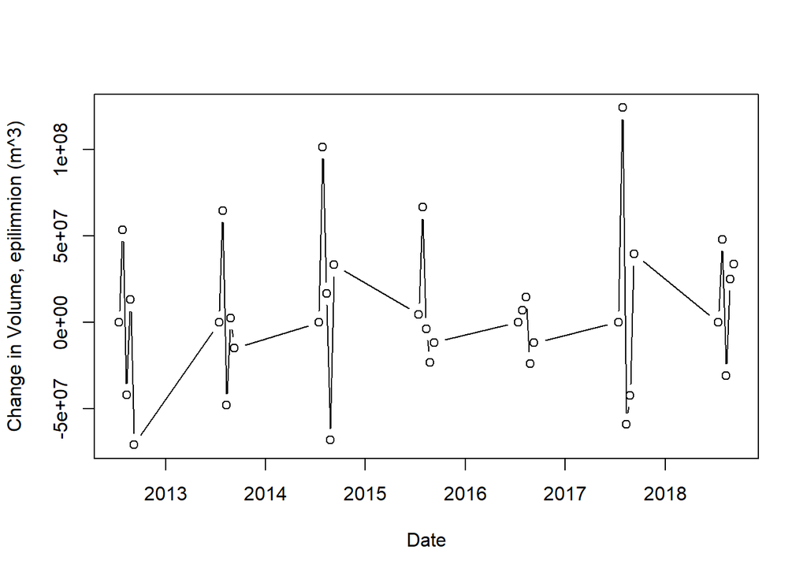

```r
Vol_epi_int$Vol_epi_m3<- na.approx(Vol_epi_int$Vol_epi_m3) #interpolates NAs
plot(x=Vol_epi_int$date, y=Vol_epi_int$Vol_epi_m3, type="b", #plots new data
     xlab="Date",
     ylab="Change in Volume, epilimnion (m^3)")
```

Missing data interpolated.

# Step 8. Save data as new data file.

```r
Vol_epi_int <- Vol_epi_int %>% select(date, Vol_epi_m3, Thermo_depth_m)
write.csv(Vol_epi_int, file="Cleaned_data/Mendota_EpiVolume.csv")
```

Data saved as new file in Cleaned_data folder as Mendota_EpiVolume.csv”